# Dota 2 High-Skill Player Behavioral Analysis

## Feature Engineering

```r
matches <- raw_matches %>%
  mutate(
    match_date   = as_datetime(start_time),
    duration_min = duration / 60,
    kda          = (kills + assists) / pmax(deaths, 1),
    won          = case_when(
      !is.na(player_slot) & !is.na(radiant_win) &
        player_slot < 128  & radiant_win        ~ TRUE,
      !is.na(player_slot) & !is.na(radiant_win) &
        player_slot >= 128 & !radiant_win        ~ TRUE,
      TRUE ~ FALSE
    ),
    party_play   = !is.na(party_size) & party_size > 1,
    left_match   = !is.na(leaver_status) & leaver_status > 0
  ) %>%
  arrange(account_id, match_date) %>%
  group_by(account_id) %>%
  mutate(
    days_since_last = as.numeric(
      difftime(match_date, lag(match_date), units = "days")
    ),
    rolling_kda = rollmeanr(kda, k = 5, fill = NA),
    match_seq   = row_number()
  ) %>%
  ungroup()

# --- Player-level behavioral profiles ---
player_profiles <- matches %>%
  group_by(account_id) %>%
  summarise(
    n_matches       = n(),
    avg_kda         = mean(kda,              na.rm = TRUE),
    kda_sd          = sd(kda,                na.rm = TRUE),
    win_rate        = mean(as.numeric(won),  na.rm = TRUE),
    median_gap      = median(days_since_last, na.rm = TRUE),
    mean_gap        = mean(days_since_last,   na.rm = TRUE),
    pct_gap_over7   = mean(days_since_last > 7, na.rm = TRUE),
    solo_rate       = mean(!party_play,      na.rm = TRUE),
    leave_rate      = mean(left_match,       na.rm = TRUE),
    avg_duration    = mean(duration_min,     na.rm = TRUE),
    span_weeks      = as.numeric(
      difftime(max(match_date), min(match_date), units = "weeks")
    ) + 1,
    .groups         = "drop"
  ) %>%
  mutate(matches_per_week = n_matches / span_weeks) %>%
  filter(n_matches >= 5)

cat("Player profiles constructed:", nrow(player_profiles))
```

```
## Player profiles constructed: 35
```

| Feature | Definition | Behavioral Signal |
| --- | --- | --- |
| `kda` | (Kills + Assists) / max(Deaths, 1) | Composite match performance |
| `won` | Derived from player_slot and radiant_win | Match outcome |
| `days_since_last` | Days between consecutive matches for each player | Inactivity proxy |
| `party_play` | party_size > 1 | Social engagement |
| `left_match` | leaver_status > 0 | Friction or frustration signal |
| `median_gap` | Median inactivity gap per player | Engagement regularity |
| `pct_gap_over7` | Share of gaps exceeding 7 days | Episodic play tendency |
| `matches_per_week` | Matches per week over active span | Play intensity |

## Engagement Analysis

### Inactivity Gap Distribution

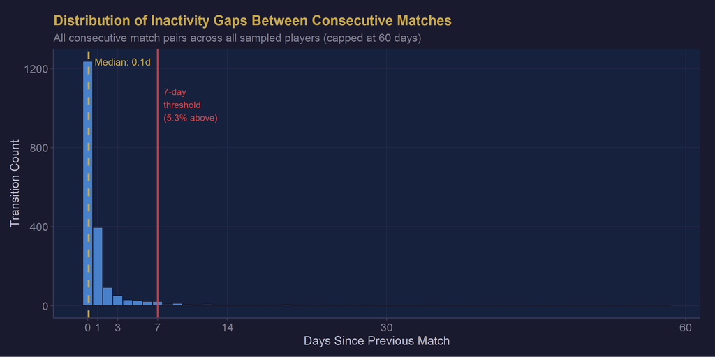

```r
gap_data <- matches %>%
  filter(!is.na(days_since_last), days_since_last >= 0, days_since_last <= 60)

med_gap  <- median(gap_data$days_since_last)
pct_sub1 <- mean(gap_data$days_since_last < 1) * 100
pct_over7 <- mean(gap_data$days_since_last > 7) * 100

gap_data %>%
  ggplot(aes(x = days_since_last)) +
  geom_histogram(binwidth = 1, fill = DOTA_BLUE, color = DOTA_BG, alpha = 0.9) +
  geom_vline(xintercept = med_gap, color = DOTA_GOLD,
             linetype = "dashed", linewidth = 1) +
  geom_vline(xintercept = 7, color = DOTA_RED,
             linetype = "solid", linewidth = 0.8, alpha = 0.85) +
  annotate("text", x = med_gap + 0.6, y = Inf, vjust = 2.2, hjust = 0,
           label = paste0("Median: ", round(med_gap, 1), "d"),
           color = DOTA_GOLD, size = 3.5) +
  annotate("text", x = 7.6, y = Inf, vjust = 2.2, hjust = 0,
           label = paste0("7-day\nthreshold\n(", round(pct_over7, 1), "% above)"),
           color = DOTA_RED, size = 3.2) +
  scale_x_continuous(breaks = c(0, 1, 3, 7, 14, 30, 60)) +
  labs(
    title    = "Distribution of Inactivity Gaps Between Consecutive Matches",
    subtitle = "All consecutive match pairs across all sampled players (capped at 60 days)",
    x        = "Days Since Previous Match",
    y        = "Transition Count"
  ) +
  theme_dota()
```

> **The inactivity gap distribution is sharply right-skewed, with the dominant pattern being same-day or next-day play, but a substantial tail extending well past 7 days signals meaningful periodic disengagement.** Each observation represents the time elapsed between two consecutive matches for the same player. The gold dashed line marks the median; the red line marks the 7-day threshold, beyond which gaps are classified as genuine activity breaks rather than routine scheduling. Nearly 77.7% of transitions occur within a single day, confirming that active professionals tend to play in clusters. The 5.3% of transitions beyond 7 days are where disengagement risk is concentrated.